# PML Course Project

Lakshman

July 27, 2016

### Executive Summary:

#### APPLIED OUTPUT on 20 Cases gave 100% accuracy output as:B A B A A E D B A A B C B A E E A B B B.

#### Loading required libraries for data analysis

```r
library(caret)
library(dplyr)
```

```r
library(rpart.plot)
```

### Clean Dataset Function

#### Using cleanData function try to remove NAs and check any columns with near zero variance. apply() function detects number of NAs in each column of the dataset. ‘rm60col’ with ‘pmldf’ filters those columns with more than 60% of NAs.Total 52 columns have non zero variance.

```r
cleanData = function(pmldf) {

dfNA = data.frame(apply(is.na(pmldf),2,sum)) # NAs Exist & convert to data frame for further use
rm60col =dfNA/nrow(pmldf)>0.6

pmldf = pmldf[,!rm60col]
dim(pmldf)
#glimpse(pmldf)
apply(is.na(pmldf),2,sum) # Cheeck again for any missing values

rmNzvCol = nearZeroVar(pmldf,saveMetrics = TRUE) # all false indicate no nearzerovar variables in dataset
rmNzvCol
#nrow(rmNzvCol)
dim(pmldf)

return(data.frame(pmldf))
}
```

### loading data and initial processing of data

#### load pml train dataset and filter ‘classe’variable initially and also initial 7 columns as they are not essential for further analysis. #### Convert all variables to numeric and call ’cleanData’ function along add back ‘classe’ variable.

### No exploratory analysis given as main focus on machine learning.

```r
pt = read.csv("pml-training.csv", na.strings = c("NA","NaN","NULL","!DIV/0",""," "))
#pt = read.csv("pmltrain.csv")
ptbackup = pt

dim(pt)
```

```
## [1] 19622   160
```

```r
#glimpse(pt)
classe = factor(pt$classe)
class(classe)
```

```
## [1] "factor"
```

```r
pt= pt[,-ncol(pt)]
pt =apply(pt,2,as.numeric) # COnvert all variables to numeric & remove response variable column
```

[output not shown]

[output cut: 16 more lines]

[output not shown]

```r
#apply(pt,2,typeof)
pt = pt[,-(1:7)]  # remove till num_window as variables not required for further analysis
dim(pt)
```

```
## [1] 19622   152
```

```r
#library(dplyr)
#glimpse(pt) # Veryfying required variables intact or not
pt = cleanData(pt)
pt = data.frame(pt)

pt$classe = classe # # pt = mutate(pt,  classe =classe)
class(pt$classe)
```

```
## [1] "factor"
```

```r
#glimpse(pt)
dim(pt)
```

```
## [1] 19622    53
```

### Training the model using rpart, gbm and random forests and compare accuracies

#### No missing values so NO imputation required. create ‘trainset’ and ‘validset’. Use ‘parallel’ for multi-core processing. trained 3 models on ‘trainset’ and applied all three techniques 1)‘Decision Trees’ - with 50% accuracy on ‘validset’. 2) ‘GBM Method’ - with >96% accuracy on validset and 3) ‘random forest-RF’ method with >99% accuracy on ‘validset’ . looking at accracy both GBM and RF methods are suitable.

#### used cross validataion with 10 iterations and allowed parallel processing in ‘train’ fucntion and in trControl parameter.

```r
#library(caret)
#pt = pt[sample(n),]
sum(is.na(pt))
```

```
## [1] 0
```

```r
inTrain = createDataPartition(y=pt$classe,p=0.9,list = FALSE)

trainset = pt[inTrain,]
validset = pt[-inTrain,]

library(parallel) # parallelizing for faster output
library(doParallel)
cluster <- makeCluster(detectCores() - 1) # convention to leave 1 core for OS
registerDoParallel(cluster)

trctrl = trainControl(method = "cv", number = 10, allowParallel = TRUE )
rpart_model = train(classe~., data = trainset, method = "rpart", trControl = trctrl)
gbm_model = train(classe~., data = trainset, method = "gbm", trControl = trctrl,verbose= TRUE)
rf_model = train(classe~., data = trainset, method = "rf", trControl = trctrl)
```

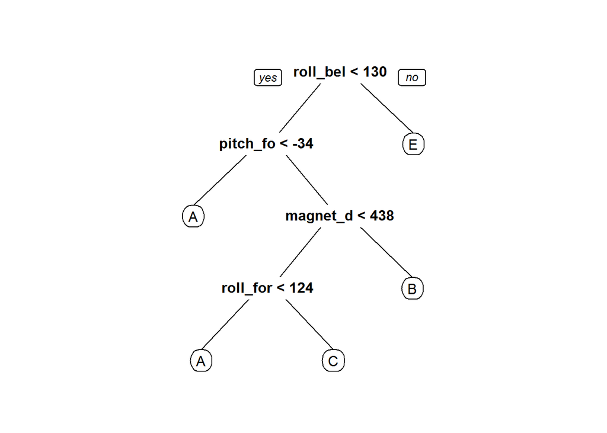

```r
stopCluster(cluster)

prp(rpart_model$finalModel)
```

```r
rpart_pred = predict(rpart_model,validset)
confusionMatrix(rpart_pred,validset$classe)
```

```
## Confusion Matrix and Statistics
##
##           Reference
## Prediction   A   B   C   D   E
##          A 510 156 171 147  36
##          B  11 137   6  63  64
##          C  37  86 165 111 102
##          D   0   0   0   0   0
##          E   0   0   0   0 158
##
## Overall Statistics
##
##                Accuracy : 0.4949
##                  95% CI : (0.4725, 0.5173)
##     No Information Rate : 0.2847
##     P-Value [Acc > NIR] : < 2.2e-16
##
##                   Kappa : 0.3395
##  Mcnemar's Test P-Value : NA
##
## Statistics by Class:
##
##                      Class: A Class: B Class: C Class: D Class: E
## Sensitivity            0.9140   0.3615  0.48246   0.0000  0.43889
## Specificity            0.6362   0.9089  0.79234   1.0000  1.00000
## Pos Pred Value         0.5000   0.4875  0.32934      NaN  1.00000
## Neg Pred Value         0.9489   0.8559  0.87868   0.8362  0.88790
## Prevalence             0.2847   0.1934  0.17449   0.1638  0.18367
## Detection Rate         0.2602   0.0699  0.08418   0.0000  0.08061
## Detection Prevalence   0.5204   0.1434  0.25561   0.0000  0.08061
## Balanced Accuracy      0.7751   0.6352  0.63740   0.5000  0.71944
```

```r
gbm_pred = predict(gbm_model,validset)
confusionMatrix(gbm_pred,validset$classe)
```

```
## Confusion Matrix and Statistics
##
##           Reference
## Prediction   A   B   C   D   E
##          A 551  11   0   0   0
##          B   6 358   8   0   4
##          C   1  10 333  13   3
##          D   0   0   1 307   3
##          E   0   0   0   1 350
##
## Overall Statistics
##
##                Accuracy : 0.9689
##                  95% CI : (0.9602, 0.9761)
##     No Information Rate : 0.2847
##     P-Value [Acc > NIR] : < 2.2e-16
##
##                   Kappa : 0.9606
##  Mcnemar's Test P-Value : NA
##
## Statistics by Class:
##
##                      Class: A Class: B Class: C Class: D Class: E
## Sensitivity            0.9875   0.9446   0.9737   0.9564   0.9722
## Specificity            0.9922   0.9886   0.9833   0.9976   0.9994
## Pos Pred Value         0.9804   0.9521   0.9250   0.9871   0.9972
## Neg Pred Value         0.9950   0.9867   0.9944   0.9915   0.9938
## Prevalence             0.2847   0.1934   0.1745   0.1638   0.1837
## Detection Rate         0.2811   0.1827   0.1699   0.1566   0.1786
## Detection Prevalence   0.2867   0.1918   0.1837   0.1587   0.1791
## Balanced Accuracy      0.9898   0.9666   0.9785   0.9770   0.9858
```

```r
rf_pred= predict(rf_model,validset)
confAcc=confusionMatrix(rf_pred,validset$classe)

errorRateRF = 1-confAcc$overall[1]
library(scales)
percent(errorRateRF)
```

```
## [1] "0.459%"
```

### Load test set, preprocess data and predict using pml-testing set

#### Load pml test set and remove initial 7 columns and apply ‘cleanData’ function for removing NA columns.Removed problem_id as it is not required. Both ‘GBM’ and ‘RF’ gives same output on testset with 100% accurate prediction (answers all 20 questions correctly in the assignment)

```r
testset = read.csv("pml-testing.csv")
dim(testset)
```

```
## [1]  20 160
```

```r
#glimpse(testset)

testset = testset[,-c(1:7)]

testset1 = cleanData(testset) # clear NAs from testset dataset
dim(testset1)
```

```
## [1] 20 53
```

```r
Pred_cases= testset1$problem_id
testset1$problem_id = NULL
rpart.test_pred = predict(rpart_model, newdata = testset1)
rpart.test_pred
```

```
##  [1] C A C A A C C A A A C C C A C A A A A C
## Levels: A B C D E
```

```r
gbm.test_pred = predict(gbm_model, newdata = testset1)
gbm.test_pred
```

```
##  [1] B A B A A E D B A A B C B A E E A B B B
## Levels: A B C D E
```

```r
rf.test_pred = predict(rf_model, newdata = testset1)
data.frame(Pred_cases, rf.test_pred)
```

```
##    Pred_cases rf.test_pred
## 1           1            B
## 2           2            A
## 3           3            B
## 4           4            A
## 5           5            A
## 6           6            E
## 7           7            D
## 8           8            B
## 9           9            A
## 10         10            A
## 11         11            B
## 12         12            C
## 13         13            B
## 14         14            A
## 15         15            E
## 16         16            E
## 17         17            A
## 18         18            B
## 19         19            B
## 20         20            B
```